# Diverse statistik for laks i Skjern Å i 2022

2023-08-07

# Alle fangster

Der blev totalt fanget 1911 laks i 2022.

Grupperet efter metode:

| Month | Spin | Orm | Flue | Andet | Totalt |
| --- | --- | --- | --- | --- | --- |
| Apr | 48 (36%) | 6 (5%) | 79 (59%) | NA | 133 (100%) |
| May | 134 (49%) | NA | 136 (50%) | 1 (0%) | 271 (100%) |
| Jun | 131 (51%) | 15 (6%) | 111 (43%) | NA | 257 (100%) |
| Jul | 187 (69%) | 9 (3%) | 73 (27%) | 1 (0%) | 270 (100%) |
| Aug | 227 (62%) | 9 (2%) | 130 (35%) | 1 (0%) | 367 (100%) |
| Sep | 170 (47%) | 6 (2%) | 185 (51%) | NA | 361 (100%) |
| Oct | 132 (52%) | 1 (0%) | 117 (46%) | 2 (1%) | 252 (100%) |
| Totalt | 1029 (54%) | 46 (2%) | 831 (43%) | 5 (0%) | 1911 (100%) |

Grupperet efter fedtfinneklippet:

| Month | Ikke klippet | Klippet | Ved ikke | Totalt |
| --- | --- | --- | --- | --- |
| Apr | 90 (68%) | 36 (27%) | 7 (5%) | 133 (100%) |
| May | 185 (68%) | 73 (27%) | 13 (5%) | 271 (100%) |
| Jun | 155 (60%) | 85 (33%) | 17 (7%) | 257 (100%) |
| Jul | 185 (69%) | 69 (26%) | 16 (6%) | 270 (100%) |
| Aug | 261 (71%) | 86 (23%) | 20 (5%) | 367 (100%) |
| Sep | 278 (77%) | 68 (19%) | 15 (4%) | 361 (100%) |
| Oct | 177 (70%) | 67 (27%) | 8 (3%) | 252 (100%) |
| Totalt | 1331 (70%) | 484 (25%) | 96 (5%) | 1911 (100%) |

Grupperet efter små og store laks (73 cm):

| Month | <=73cm | >73cm | NA | Totalt |
| --- | --- | --- | --- | --- |
| Apr | 2 (2%) | 131 (98%) | NA | 133 (100%) |
| May | 8 (3%) | 263 (97%) | NA | 271 (100%) |
| Jun | 15 (6%) | 240 (93%) | 2 (1%) | 257 (100%) |
| Jul | 97 (36%) | 173 (64%) | NA | 270 (100%) |
| Aug | 169 (46%) | 197 (54%) | 1 (0%) | 367 (100%) |
| Sep | 159 (44%) | 202 (56%) | NA | 361 (100%) |
| Oct | 108 (43%) | 143 (57%) | 1 (0%) | 252 (100%) |
| Totalt | 558 (29%) | 1349 (71%) | 4 (0%) | 1911 (100%) |

Antal fangster per fisker (antager at navne er unikke):

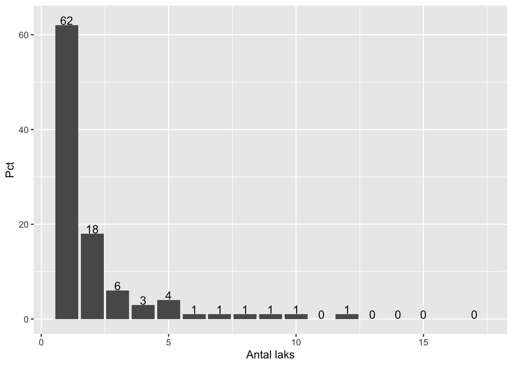

# Fangster uden fedtfinne

Bemærk vi har ikke medtaget laks fanget, hvor fedtfinne ikke er identificeret (96 stk dvs højt sat er ca. 30 a disse uden fedtfinne).

Der blev totalt fanget 484 laks i 2022.

Grupperet efter metode:

| Month | Spin | Flue | Orm | Totalt |
| --- | --- | --- | --- | --- |
| Apr | 16 (44%) | 20 (56%) | NA | 36 (100%) |
| May | 42 (58%) | 31 (42%) | NA | 73 (100%) |
| Jun | 43 (51%) | 37 (44%) | 5 (6%) | 85 (100%) |
| Jul | 54 (78%) | 15 (22%) | NA | 69 (100%) |
| Aug | 52 (60%) | 33 (38%) | 1 (1%) | 86 (100%) |
| Sep | 33 (49%) | 35 (51%) | NA | 68 (100%) |
| Oct | 33 (49%) | 33 (49%) | 1 (1%) | 67 (100%) |
| Totalt | 273 (56%) | 204 (42%) | 7 (1%) | 484 (100%) |

Grupperet efter små og store laks (73 cm):

| Month | <=73cm | >73cm | NA | Totalt |
| --- | --- | --- | --- | --- |
| Apr | 2 (6%) | 34 (94%) | NA | 36 (100%) |
| May | 3 (4%) | 70 (96%) | NA | 73 (100%) |
| Jun | 1 (1%) | 83 (98%) | 1 (1%) | 85 (100%) |
| Jul | 20 (29%) | 49 (71%) | NA | 69 (100%) |
| Aug | 39 (45%) | 47 (55%) | NA | 86 (100%) |
| Sep | 29 (43%) | 39 (57%) | NA | 68 (100%) |
| Oct | 24 (36%) | 43 (64%) | NA | 67 (100%) |
| Totalt | 118 (24%) | 365 (75%) | 1 (0%) | 484 (100%) |

I det følgende antager vi at navne er unikke (lig en person). Antal fangster per fisker (antager at navne er unikke):

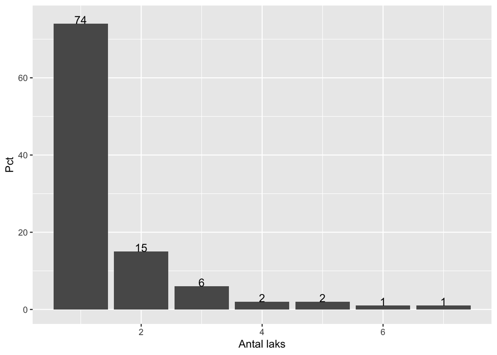

Hvor mange fiskere fanger en fedfinneklippet laks eller flere?

| Personer | fanger<=73 | fanger>73cm |
| --- | --- | --- |
| 324 | 99 | 264 |

Hvornår fanges den første fedtfinneklippet laks af en fisker?

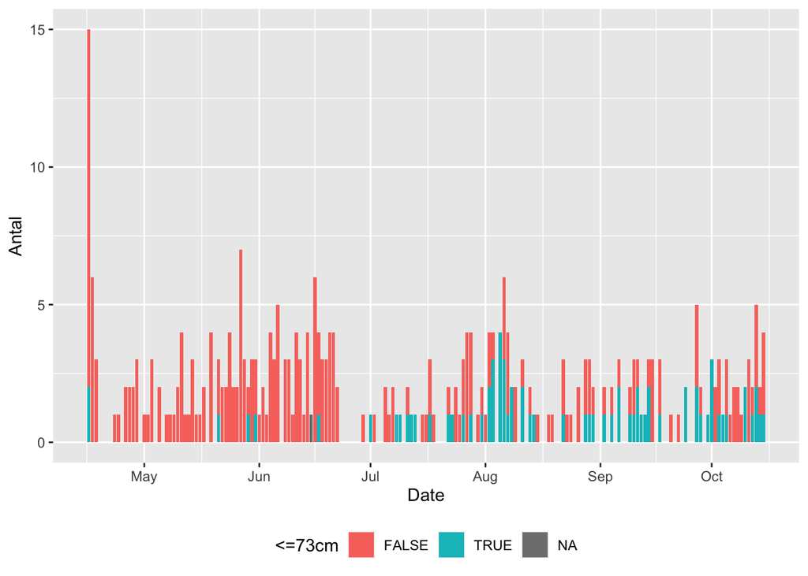

Hvis antager at fiskere genudsætter fisk under eller på 73 cm og hjemtager den første over (264 laks hjemtages):

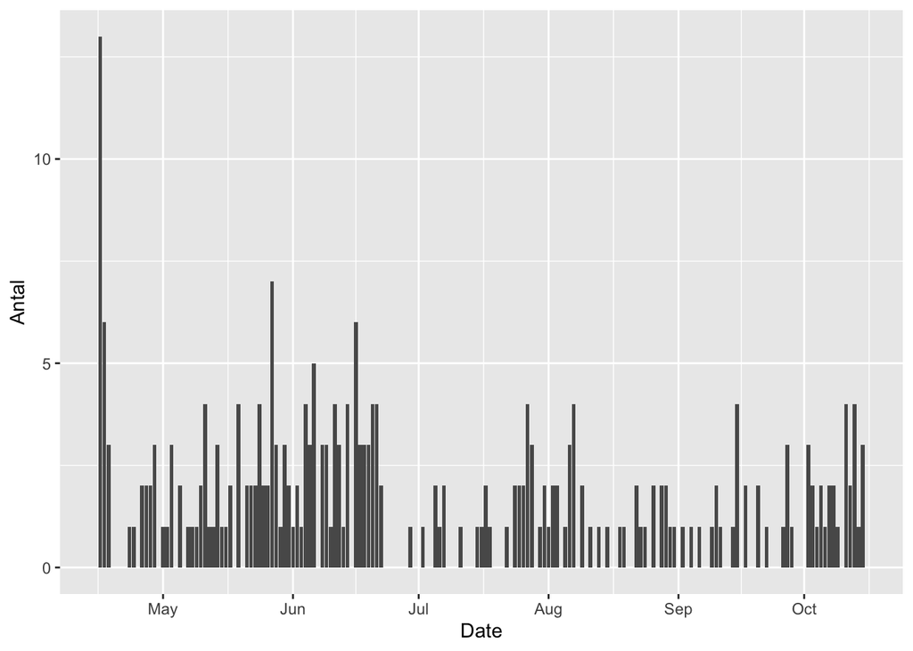

Hvis antager at fiskere genudsætter fisk under eller på 89 cm og hjemtager den første over (130 laks hjemtages):

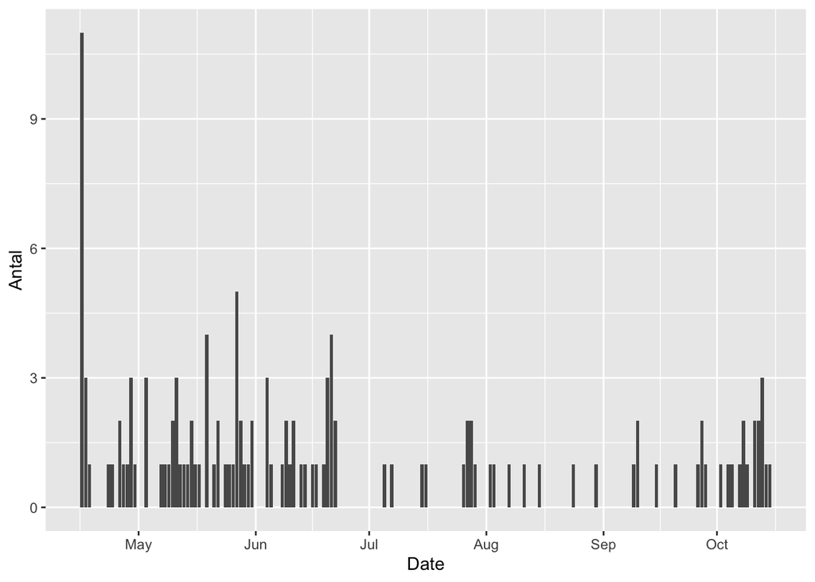

# Fangster uden fedtfinne (gennemsnit over 2018 - 2022)

Hvor mange af fangsterne er uden fedtfinne givet et område:

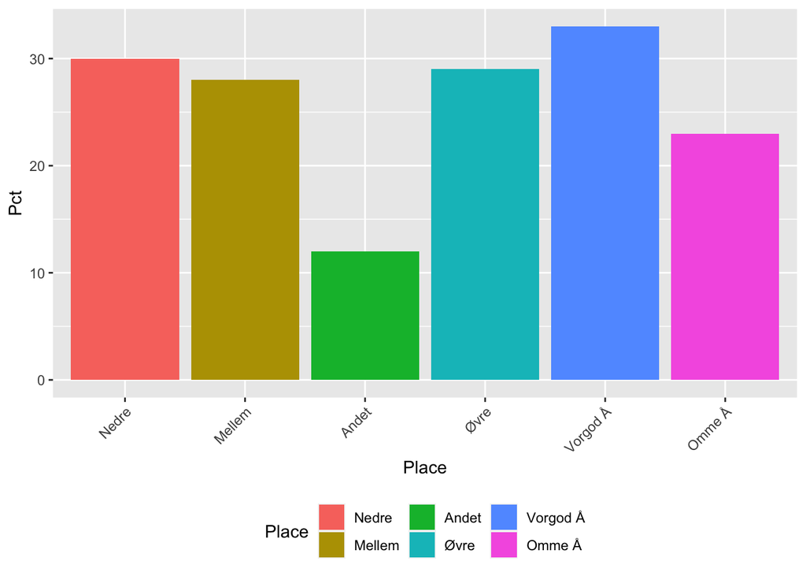

Grupperet efter metode:

| Month | Spin | Orm | Flue | Andet | Totalt |
| --- | --- | --- | --- | --- | --- |
| Apr | 14.4 (45%) | 0.6 (2%) | 17 (53%) | NA | 32 (100%) |
| May | 20.8 (50%) | 0.6 (1%) | 20 (48%) | 0.2 (0%) | 41.6 (100%) |
| Jun | 37.6 (53%) | 3.6 (5%) | 29.8 (42%) | NA | 71 (100%) |
| Jul | 41 (63%) | 0.8 (1%) | 23 (35%) | 0.2 (0%) | 65 (100%) |
| Aug | 71.8 (60%) | 1.4 (1%) | 47.2 (39%) | NA | 120.4 (100%) |
| Sep | 48 (48%) | 1.4 (1%) | 50 (50%) | 0.2 (0%) | 99.6 (100%) |
| Oct | 29.8 (45%) | 1 (2%) | 34.8 (53%) | 0.2 (0%) | 65.8 (100%) |
| Totalt | 263.4 (53%) | 9.4 (2%) | 221.8 (45%) | 0.8 (0%) | 495.4 (100%) |

Grupperet efter små og store laks (73 cm):

| Month | <=73cm | >73cm | NA | Totalt |
| --- | --- | --- | --- | --- |
| Apr | 0.8 (2%) | 30.4 (95%) | 0.8 (2%) | 32 (100%) |
| May | 0.8 (2%) | 40.8 (98%) | NA | 41.6 (100%) |
| Jun | 1.6 (2%) | 69.2 (97%) | 0.2 (0%) | 71 (100%) |
| Jul | 11.2 (17%) | 53.6 (82%) | 0.2 (0%) | 65 (100%) |
| Aug | 57.2 (48%) | 61.6 (51%) | 1.6 (1%) | 120.4 (100%) |
| Sep | 45.6 (46%) | 53.6 (54%) | 0.4 (0%) | 99.6 (100%) |
| Oct | 24.2 (37%) | 41.6 (63%) | NA | 65.8 (100%) |
| Totalt | 141.4 (29%) | 350.8 (71%) | 3.2 (1%) | 495.4 (100%) |

I det følgende antager vi at navne er unikke (lig en person). Antal fangster per fisker (antager at navne er unikke):

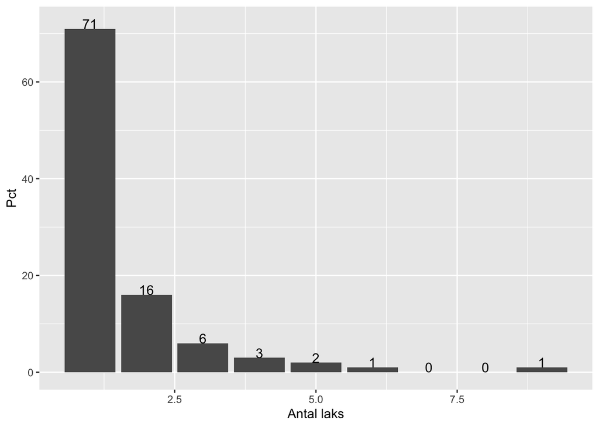

Hvor mange fiskere fanger en fedfinneklippet laks eller flere?

| Year | Personer | fanger<=73 | fanger>73cm |
| --- | --- | --- | --- |
| 2018 | 353 | 204 | 221 |
| 2019 | 346 | 43 | 330 |
| 2020 | 311 | 134 | 214 |
| 2021 | 285 | 98 | 216 |
| 2022 | 324 | 99 | 264 |

Hvornår fanges den første fedtfinneklippet laks af en fisker?

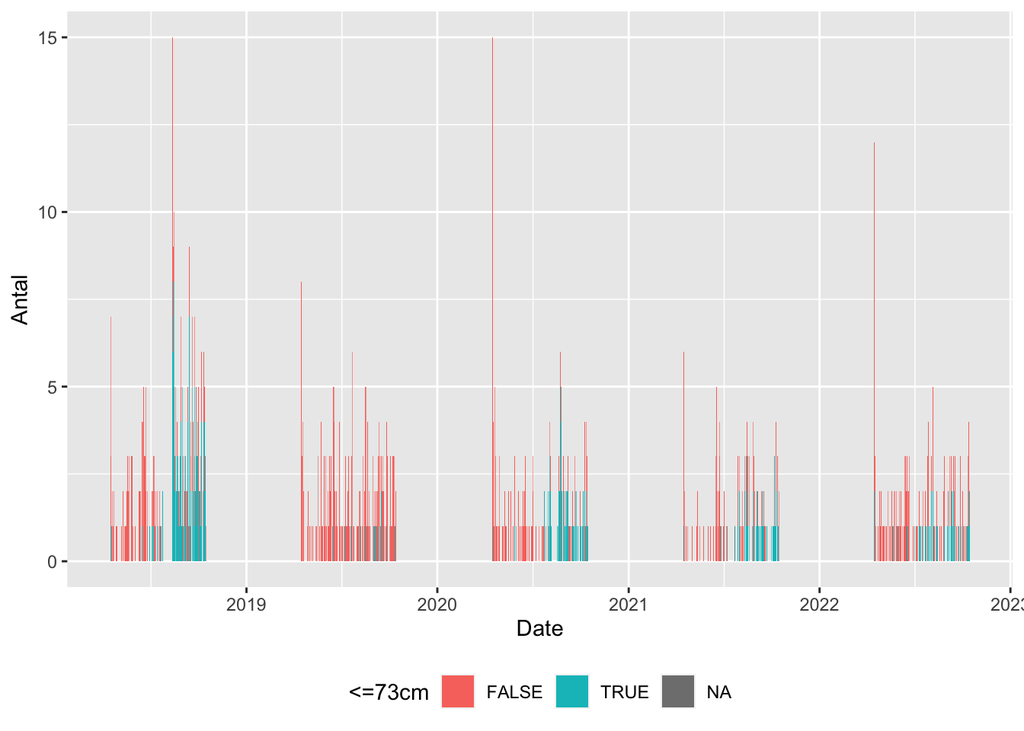

Hvis antager at fiskere genudsætter fisk under eller på 73 cm og hjemtager den første over:

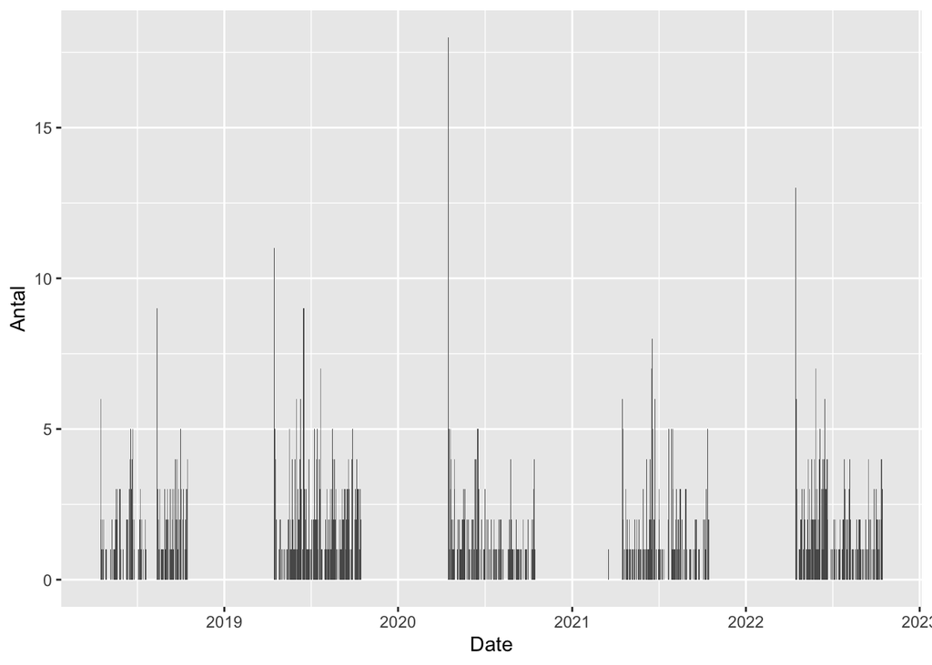

Hvis antager at fiskere genudsætter fisk under eller på 89 cm og hjemtager den første over:

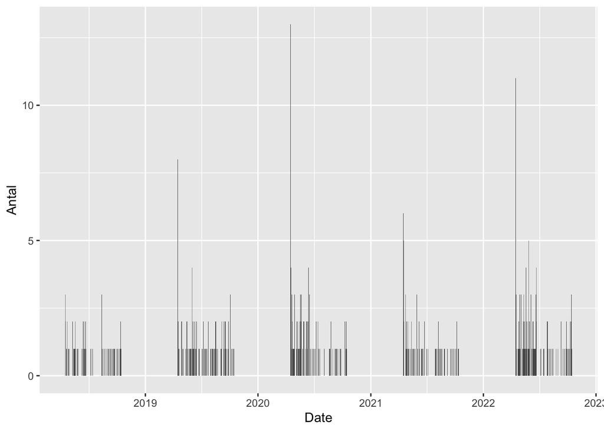